# Reproducible Data Course Project

Arjen Hunter

23 January 2019

# Introduction

In this assignment I use data from a personal activity monitoring device. This device collects data at 5 minute intervals through out the day. The data consists of two months of data from an anonymous individual collected during the months of October and November, 2012 and include the number of steps taken in 5 minute intervals each day.

This assignment is intended to show my proficiency in R by completing a complete assignments and a series of questions in a single R markdown document. The document can be processed by knitr and be transformed into an HTML file.

## Loading and preprocessing the data

Show any code that is needed to

1. Load the data (i.e. read.csv())
2. Process/transform the data (if necessary) into a format suitable for your analysis

```r
suppressMessages(library(readr))
suppressMessages(library(lubridate))
suppressMessages(library(dplyr))
activity <- read_csv("activity.csv",
  col_types = cols(date = col_character(),
  interval = col_number(), steps = col_number()),
  na = "NA")
```

## Eyeball the data

Let’s see what we have in terms of data type, completeness and how it is sorted. According to the documentation the variables included in this dataset are:

-steps: Number of steps taking in a 5-minute interval (missing values are coded as NA)  
-date: The date on which the measurement was taken in YYYY-MM-DD format  
-interval: Identifier for the 5-minute interval in which measurement was taken  
The dataset is stored in a comma-separated-value (CSV) file and there are a total of 17,568 observations in this dataset.

```r
## Eyeball the data and put everything in an appropriate format
str(activity); dim(activity); head(activity);summary(activity)
```

```
## Classes 'spec_tbl_df', 'tbl_df', 'tbl' and 'data.frame': 17568 obs. of  3 variables:
##  $ steps   : num  NA NA NA NA NA NA NA NA NA NA ...
##  $ date    : chr  "2012-10-01" "2012-10-01" "2012-10-01" "2012-10-01" ...
##  $ interval: num  0 5 10 15 20 25 30 35 40 45 ...
##  - attr(*, "spec")=
##   .. cols(
##   ..   steps = col_number(),
##   ..   date = col_character(),
##   ..   interval = col_number()
##   .. )
```

```
## [1] 17568     3
```

```
## # A tibble: 6 x 3
##   steps date       interval
##   <dbl> <chr>         <dbl>
## 1    NA 2012-10-01        0
## 2    NA 2012-10-01        5
## 3    NA 2012-10-01       10
## 4    NA 2012-10-01       15
## 5    NA 2012-10-01       20
## 6    NA 2012-10-01       25
```

```
##      steps            date              interval
##  Min.   :  0.00   Length:17568       Min.   :   0.0
##  1st Qu.:  0.00   Class :character   1st Qu.: 588.8
##  Median :  0.00   Mode  :character   Median :1177.5
##  Mean   : 37.38                      Mean   :1177.5
##  3rd Qu.: 12.00                      3rd Qu.:1766.2
##  Max.   :806.00                      Max.   :2355.0
##  NA's   :2304
```

```r
suppressMessages(library(lubridate))
activity$date <- ymd(activity$date)
```

The data does indeed contain 3 variables with 17,568 datapoints and be sorted by the date, though the date is not stored as such. It is actually stored as text. So that is the first thing to correct. For doing so, the lubridate package is required.

## 1. Calculate the total number of steps taken per day

Every individual day contains various 5-minute measurements. We want to report the total number of steps taken on each day. In order to do so, I aggregate the data by date, using the sum function. It is stored in a dataframe with an entry for each of the 61 unique date, including those dates having only NA.

```r
sum <- aggregate(activity$steps, by=list(Category=activity$date), FUN=sum)
str(sum)
```

```
## 'data.frame':    61 obs. of  2 variables:
##  $ Category: Date, format: "2012-10-01" "2012-10-02" ...
##  $ x       : num  NA 126 11352 12116 13294 ...
```

## 2. A histogram of the total number of steps taken each day

With bar charts, the labels on the X axis are categorical; with histograms, the labels are quantitative. By giving the plot an impressive color scheme, we draw the attention away from that aspect.

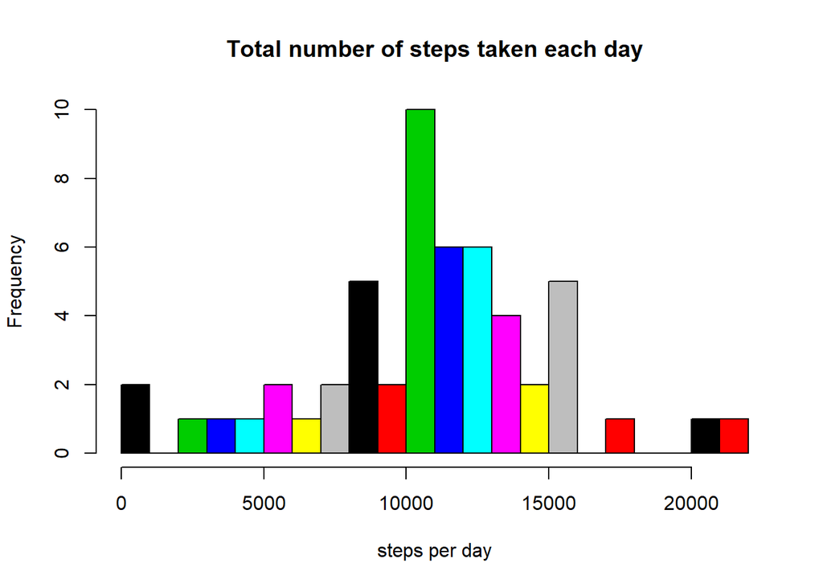

```r
hist(sum$x,
     main="Total number of steps taken each day",
     xlab="steps per day",breaks=20,
     col=(1:20)
)
```

## 3. Calculate the mean and median

The mean and median of the total number of steps taken per day can be calculated by actual day. It can also be calculated over the total, since that was measured per day. So to prevent misunderstandings and since I need the practise, let do both. First, let’s calculate the mean and median in for each day.

```r
mean <- aggregate(activity$steps, by=list(Category=activity$date), FUN=mean)
median <- aggregate(activity$steps, by=list(Category=activity$date), FUN=median)
str(mean); str(median)
```

```
## 'data.frame':    61 obs. of  2 variables:
##  $ Category: Date, format: "2012-10-01" "2012-10-02" ...
##  $ x       : num  NA 0.438 39.417 42.069 46.16 ...
```

```
## 'data.frame':    61 obs. of  2 variables:
##  $ Category: Date, format: "2012-10-01" "2012-10-02" ...
##  $ x       : num  NA 0 0 0 0 0 0 NA 0 0 ...
```

Secondly, for the fun of it, let’s calculate the overall the mean and median, without actually storing them.

```r
mean(na.omit(sum$x))
```

```
## [1] 10766.19
```

```r
median(na.omit(sum$x))
```

```
## [1] 10765
```

## 4. Time series plot of the average number of steps taken

Here I’m assuming the intention is to plot the average number of steps per days and not overall. Additionally I’ve added the mean in red to give an impression where it is located.

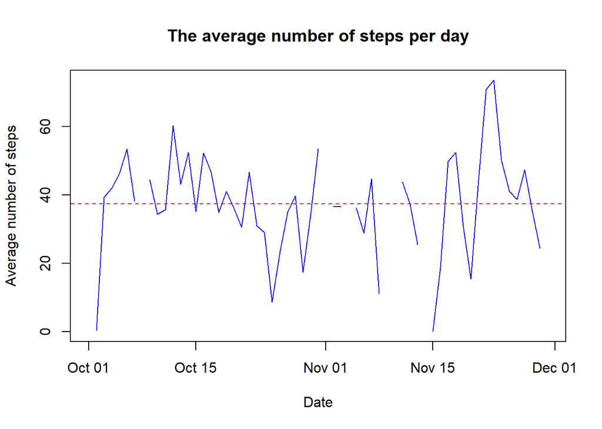

```r
plot(mean$Category,mean$x,type="l",
     main=("The average number of steps per day"),
     xlab="Date",
     ylab="Average number of steps",
     col="blue"
    )
abline(h=mean(na.omit(mean$x)), lty=2,col="red")
```

## 5. The 5-minute interval that contains the maximum number

Determine the number of the interval that contains the maximum number of steps. By reverse sorting the data by the number of steps, we ensure the first cell of the dataframe contains the maximum. The number of the 5-minute interval is in the interval column.

```r
arrange(activity,-steps)$interval[1]
```

```
## [1] 615
```